# Introduction to Biostatistics

# 1 Learning objectives

## 1.1 Learning objectives

- Describe the logic of **linear regression**
- Describe the **assumptions** of linear regression
- Briefly **present results** of linear regression
- Use a **regression equation** to summarize a model
- Compare and contrast **observed**, **predicted**, and **residual** values

# 2 Motivation

## 2.1 Linear regression

- General linear model or **GLM**
  - Includes linear regression, ANOVA, $t$-tests
- One **dependent variable** or **outcome**
  - Predicted by 1 or more continuous or categorical **independent variables** or **predictors**
- Causality not assumed, but sometimes (wrongly) implied

## 2.2 Purposes of linear regression

- **Inference**
  - Confirm effect of predictor(s) on outcome
- **Prediction**
  - Predict outcome value based on predictor value(s)
- **Variance explained**
  - How much of the variance in the outcome is explained by the predictor(s)?

## 2.3 Assumptions

- **One** *continuous* outcome variable
- **One or more** predictor variable (nominal, ordinal, interval, ratio)
- Relationship is **linear in the predictors**
- Observations are **independent** (uncorrelated)
- **Residuals** are *conditionally normally distributed* with *constant variance* (homoscedasticity)

# 3 Example

## 3.1 Data

- `ICU` data from the **Stat2Data** package
  - `ID`: Patient ID code
  - `Survive`: 1 = patient survived to discharge or 0 = patient died
  - `Age`: Age (in years)
  - `AgeGroup`: 1 = young (under 50), 2 = middle (50-69), 3 = old (70+)
  - `Sex`: 1 = female or 0 = male
  - `Infection`: 1 = infection suspected or 0 = no infection
  - `SysBP`: Systolic blood pressure (in mm of Hg)
  - `Pulse`: Heart rate (beats per minute)
  - `Emergency`: 1 = emergency admission or 0 = elective admission

## 3.2 Data

```r
library(Stat2Data)
data(ICU)
head(ICU)
```

```
  ID Survive Age AgeGroup Sex Infection SysBP Pulse Emergency
1  4       0  87        3   1         1    80    96         1
2  8       1  27        1   1         1   142    88         1
3 12       1  59        2   0         0   112    80         1
4 14       1  77        3   0         0   100    70         0
5 27       0  76        3   1         1   128    90         1
6 28       1  54        2   0         1   142   103         1
```

## 3.3 Relations between variables

- Y versus X
- Y as a function of X
- `Y ~ X`
- X predicts Y

## 3.4 Example 1: `Pulse` vs `Age`

- Does `Pulse` depend on `Age`?

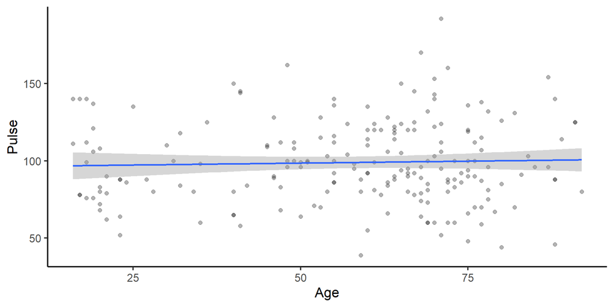

```r
ggplot(data = ICU,
       aes(x = Age, y = Pulse)) +
  geom_point(alpha = 0.3,
             size = 2) +
  geom_smooth(method = "lm",
              se = TRUE)
```

## 3.5 Example 2: `Pulse` vs `Emergency`

- Do emergency and non-emergency admits have similar `Pulse` rates?

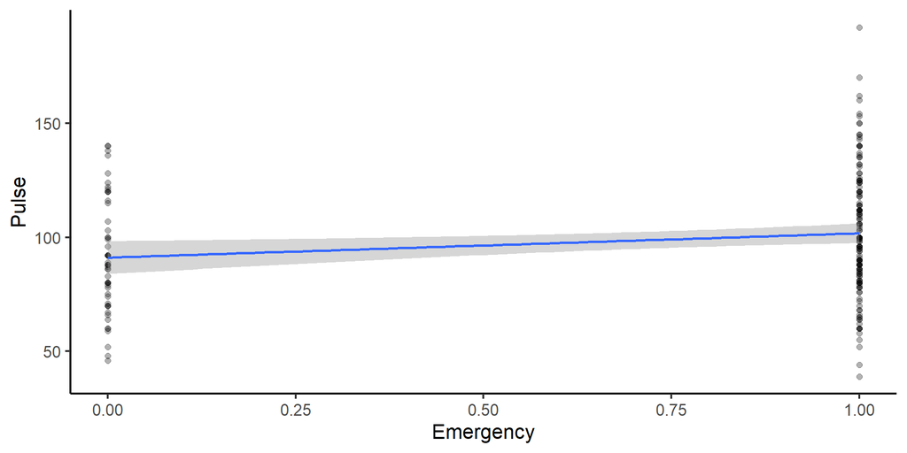

```r
ggplot(data = ICU,
       aes(x = Emergency, y = Pulse)) +
  geom_point(alpha = 0.3,
             size = 2) +
  geom_smooth(method = "lm",
              se = TRUE)
```

# 4 Inference

## 4.1 `lm()` function

- `lm()` function in **stats** package (loaded by default)
- Inputs
  - `data`: data frame
  - `formula`: relationship to model (`Y ~ X`)
- Outputs
  - `coefficients`, `residuals`, etc.
  - See [documentation](https://www.rdocumentation.org/packages/stats/versions/3.6.2/topics/lm)

## 4.2 Example 1: `Pulse` vs `Age`

```r
pulse_vs_age <- lm(data = ICU, Pulse ~ Age)
summary(pulse_vs_age)
```

```
Call:
lm(formula = Pulse ~ Age, data = ICU)

Residuals:
    Min      1Q  Median      3Q     Max
-59.998 -18.098  -4.123  19.452  92.402

Coefficients:
            Estimate Std. Error t value Pr(>|t|)
(Intercept) 96.04818    5.78821  16.594   <2e-16 ***
Age          0.04999    0.09501   0.526    0.599
---
Signif. codes:  0 '***' 0.001 '**' 0.01 '*' 0.05 '.' 0.1 ' ' 1

Residual standard error: 26.88 on 198 degrees of freedom
Multiple R-squared:  0.001396,  Adjusted R-squared:  -0.003647
F-statistic: 0.2769 on 1 and 198 DF,  p-value: 0.5993
```

## 4.4 Example 2: `Pulse` vs `Emergency`

```r
pulse_vs_ER <- lm(data = ICU, Pulse ~ Emergency)
summary(pulse_vs_ER)
```

```
Call:
lm(formula = Pulse ~ Emergency, data = ICU)

Residuals:
    Min      1Q  Median      3Q     Max
-62.741 -17.741  -2.927  18.259  90.259

Coefficients:
            Estimate Std. Error t value Pr(>|t|)
(Intercept)   91.113      3.637  25.049   <2e-16 ***
Emergency     10.628      4.243   2.505   0.0131 *
---
Signif. codes:  0 '***' 0.001 '**' 0.01 '*' 0.05 '.' 0.1 ' ' 1

Residual standard error: 26.48 on 198 degrees of freedom
Multiple R-squared:  0.03072,   Adjusted R-squared:  0.02582
F-statistic: 6.275 on 1 and 198 DF,  p-value: 0.01305
```

## 4.5 Example 2: `Pulse` vs `Emergency`

- Intercept = Expected `Pulse` when `Emergency` = 0
  - $b_0$ = 91.113, $t(1)$ = 25.049, $p$ < .0001
  - `Pulse` for a person w non-emergency admit is 91.113
- Slope = Expected change in `Pulse` for a 1 unit difference in `Emergency`
  - $b_1$ = 10.628, $t(1)$ = 2.505, $p$ < .05
  - For each 1 unit increase in `Emergency`, we expect `Pulse` to increase by 10.628 points
  - **Group difference** (0 to 1) is 10.628 points

## 4.6 Regression equations

- Two forms
  - $\hat{Y} = b_0 + b_1 X_1 + b_2 X_2 + \cdots$
    - **Predicted Y** is a function of coefficients and predictors
  - $Y = b_0 + b_1 X_1 + b_2 X_2 + \cdots + error$
    - **Observed Y** is a function of coefficients and predictors, **plus error**

## 4.7 Regression equations

- Example 1:
  - $\hat{Pulse} = 96.048 + 0.049*Age$
- Example 2:
  - $\hat{Pulse} = 91.113 + 10.628*Emergency$

## 4.8 How to describe slopes

- For each **1 unit increase** (or **1 unit change** or **1 unit difference**) in `X`, we expect `Y` to increase by $b_1$ points on average
  - Are we **increasing** or **changing** `X`?
  - In these models (and often), no
- For **two individuals who are 1 unit apart** on `X`, we expect their scores on `Y` to differ by $b_1$ points on average
  - This is a *mouthful* but more technically accurate

## 4.9 Reporting $p$-values

- Non-significant effect
  - Thresholds: $b_1$ = 0.049, $t(1)$ = 0.526, $p$ > .05
  - Exact $p$-value: $b_1$ = 0.049, $t(1)$ = 0.526, $p$ = .599
  - Not significant: $b_1$ = 0.049, $t(1)$ = 0.526, NS
- Significant effect
  - Thresholds: $b_1$ = 10.628, $t(1)$ = 2.505, $p$ < .05
  - Exact $p$-value: $b_1$ = 10.628, $t(1)$ = 2.505, $p$ = .0131
- $p$-value is **never** 0: Report $p$ < .001 or similar

# 5 Prediction

## 5.1 Observed and predicted values

- **Observed** values of the outcome in the dataset
  - One value per observation
  - Observed outcome: $Y$
- **Predicted** values of the outcome that are **predicted** by the model
  - One value per observation
  - Predicted outcome: $\hat{Y}$
  - Use the regression equation to calculate

## 5.2 Predicted values

- Example 1: `Pulse ~ Age`
  - `Age` = 87: $\hat{Pulse} = 96.048 + 0.049 * 87 = 100.311$
  - `Age` = 27: $\hat{Pulse} = 96.048 + 0.049 * 27 = 97.371$
  - `Age` = 59: $\hat{Pulse} = 96.048 + 0.049 * 59 = 98.939$
  - `Age` = 0: $\hat{Pulse} = 96.048 + 0.049 * 0 = 96.048$
  - Etc. for each value of `Age`

## 5.3 Predicted values

- Example 2: `Pulse ~ Emergency`
  - Emergency = 0: $\hat{Pulse} = 91.113 + 10.628 * 0 = 91.113$
  - Emergency = 1: $\hat{Pulse} = 91.113 + 10.628 * 1 = 101.741$

## 5.4 Predicted values

- `predict()` function in R
  - Talk more about this in coming weeks
  - Can use to create predicted values for
    - Original data
    - All possible values
    - Specific values

## 5.5 Example 1: Observed and predicted

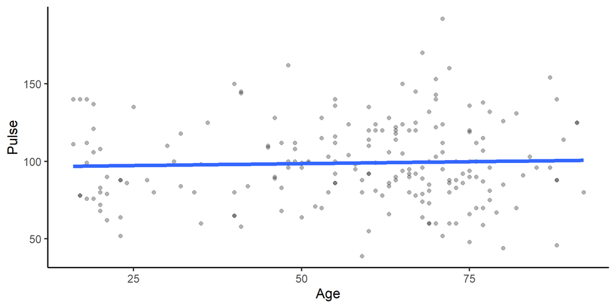

```r
ggplot(data = ICU,
       aes(x = Age, y = Pulse)) +
  geom_point(alpha = 0.3,
             size = 2) +
  geom_smooth(method = "lm",
              se = FALSE,
              size = 2)
```

## 5.6 Example 2: Observed and predicted

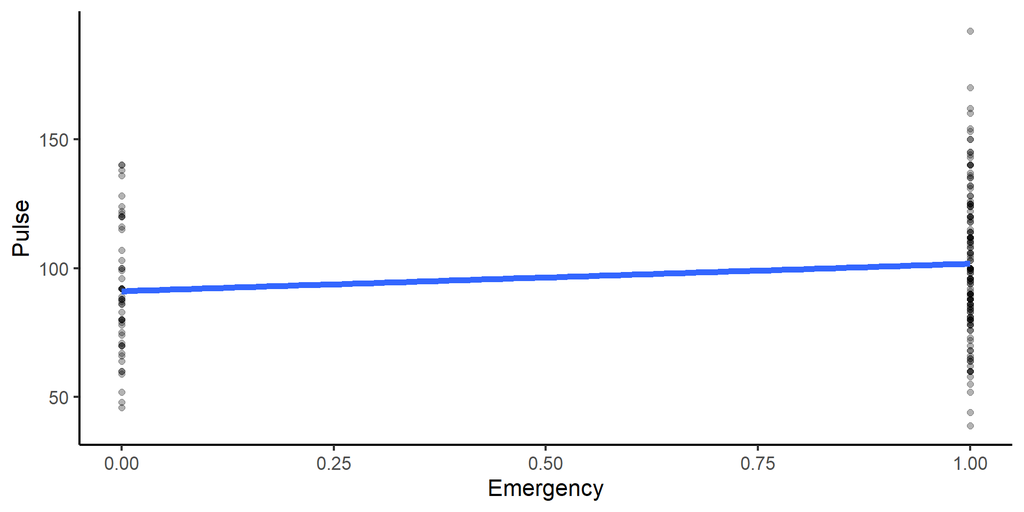

```r
ggplot(data = ICU,
       aes(x = Emergency, y = Pulse)) +
  geom_point(alpha = 0.3,
             size = 2) +
  geom_smooth(method = "lm",
              se = FALSE,
              size = 2)
```

## 5.7 Residual values

- Residuals are the *difference* between the **observed** and **predicted** values **for an observation**
  - One residual per observation
  - Residual: $Y - \hat{Y}$
- Assumptions for **residuals**
  - *Constant variance* (homoscedasticity)
  - *Conditionally normally distributed*

## 5.8 Predicted and residual values

```r
ICU$pred1 <- fitted(pulse_vs_age)
ICU$resi1 <- residuals(pulse_vs_age)
ICU$pred2 <- fitted(pulse_vs_ER)
ICU$resi2 <- residuals(pulse_vs_ER)
head(ICU)
```

```
  ID Survive Age AgeGroup Sex Infection SysBP Pulse Emergency     pred1
1  4       0  87        3   1         1    80    96         1 100.39753
2  8       1  27        1   1         1   142    88         1  97.39798
3 12       1  59        2   0         0   112    80         1  98.99774
4 14       1  77        3   0         0   100    70         0  99.89760
5 27       0  76        3   1         1   128    90         1  99.84761
6 28       1  54        2   0         1   142   103         1  98.74778
       resi1     pred2      resi2
1  -4.397527 101.74150  -5.741497
2  -9.397981 101.74150 -13.741497
3 -18.997739 101.74150 -21.741497
4 -29.897603  91.11321 -21.113208
5  -9.847611 101.74150 -11.741497
6   4.252223 101.74150   1.258503
```

## 5.9 What is the residual?

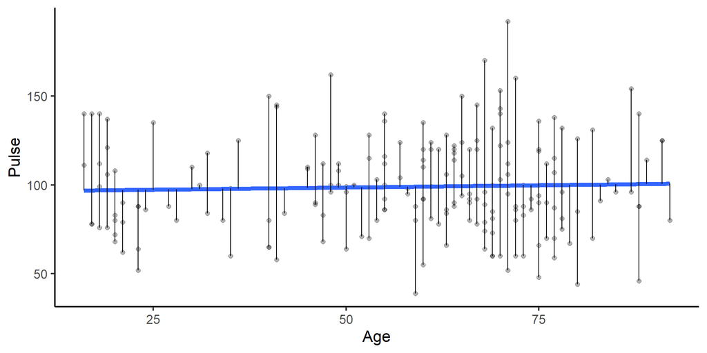

```r
ggplot(data = ICU,
       aes(x = Age, y = Pulse)) +
  geom_point(alpha = 0.3,
             size = 2) +
  geom_smooth(method = "lm",
              se = FALSE,
              size = 2) +
  geom_segment(aes(x = Age,
                   xend = Age,
                   y = Pulse,
                   yend = pred1))
```

## 5.10 Constant variance?

- Plot residual vs predictor

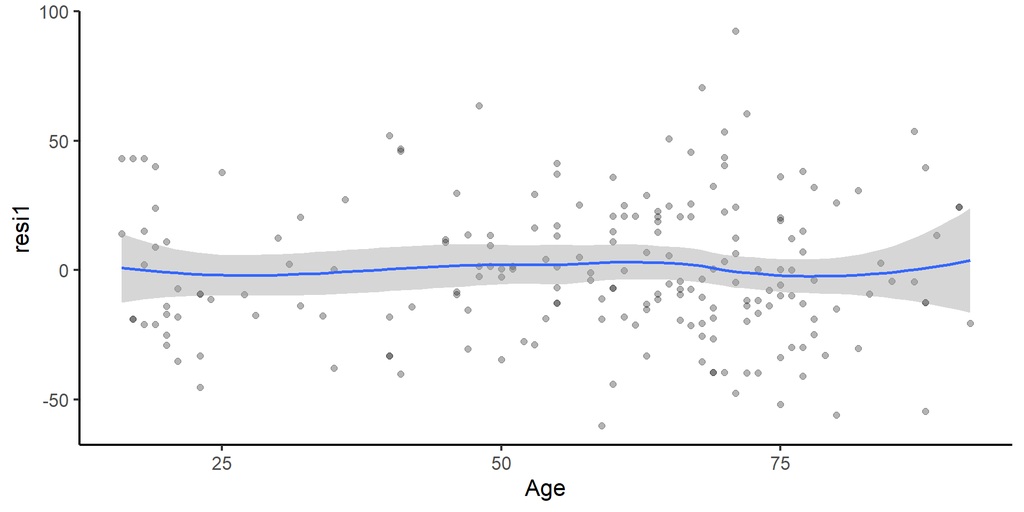

```r
ggplot(data = ICU,
       aes(x = Age, y = resi1)) +
  geom_point(alpha = 0.3,
             size = 2) +
  geom_smooth()
```

## 5.11 Constant variance?

- Plot residual vs predicted (for more than 1 predictor)

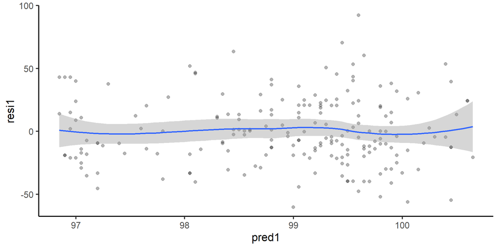

```r
ggplot(data = ICU,
       aes(x = pred1, y = resi1)) +
  geom_point(alpha = 0.3,
             size = 2) +
  geom_smooth()
```

## 5.12 Normally distributed?

- Q-Q plot (overall distribution)

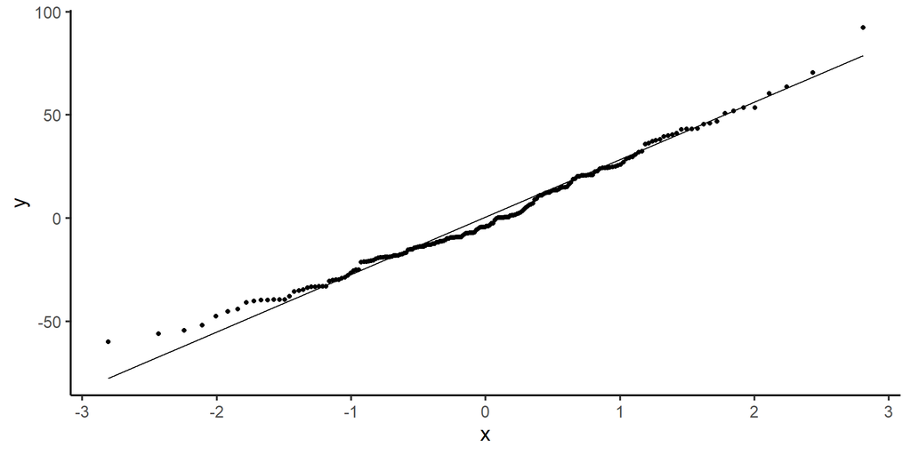

```r
ggplot(data = ICU,
       aes(sample = resi1)) +
       stat_qq() +
       stat_qq_line()
```

## 5.13 Normally distributed?

- Histogram

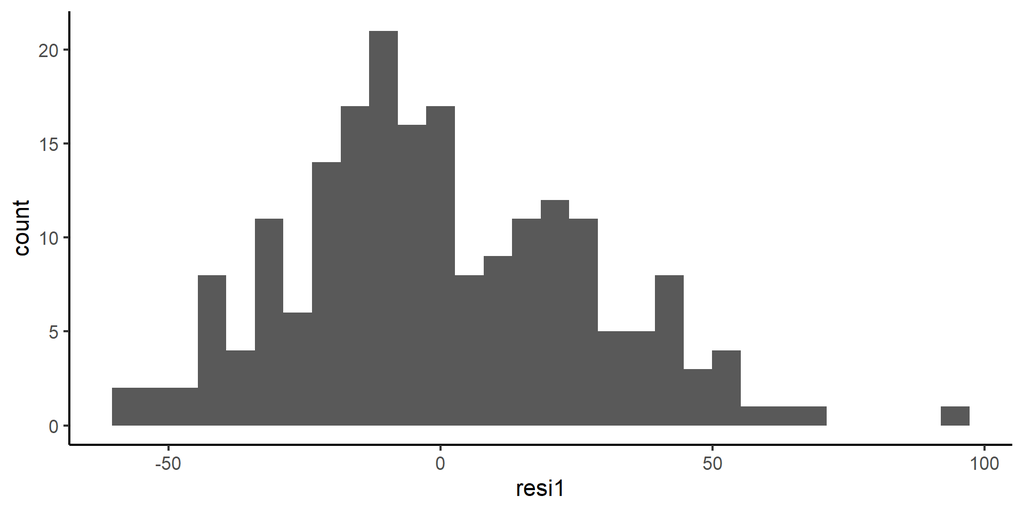

```r
ggplot(data = ICU,
       aes(x = resi1)) +
  geom_histogram()
```

## 5.14 (Conditionally) Normally distributed?

- Histogram **at each level of predictor**

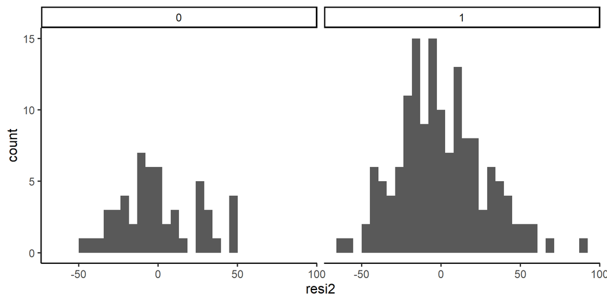

```r
ggplot(data = ICU,
       aes(x = resi2)) +
  geom_histogram() +
  facet_grid(cols = vars(Emergency))
```

## 5.15 Constant variance?

- Plot residual vs predictor

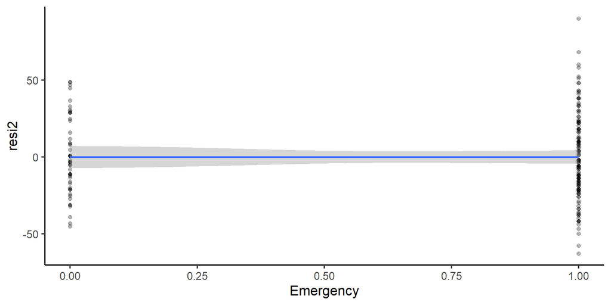

```r
ggplot(data = ICU,
       aes(x = Emergency, y = resi2)) +
  geom_point(alpha = 0.3,
             size = 2) +
  geom_smooth()
```

# 6 Variance explained

## 6.1 R-squared multiple

- One number summary of the predictive power of the model
  - Proportion: Ranges from 0 to 1
    - 0 = predictor(s) explain **no variance** in outcome
    - 1 = predictor(s) explain **all variance** in outcome
- **Squared correlation** (between observed and predicted values)
  - **Effect size** for the *model*
  - Other definitions related to *estimation*

## 6.2 Correlations

- Correlation = 0.2
  - $R^2$ = 0.04

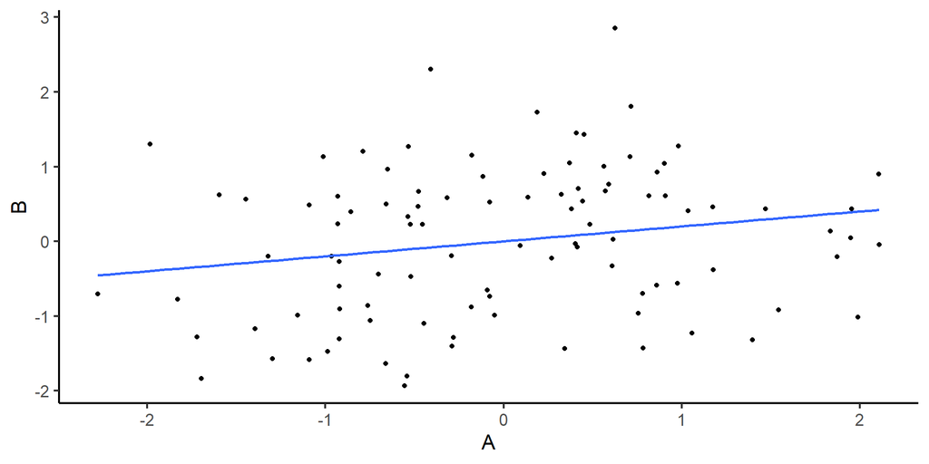

- Correlation = 0.8
  - $R^2$ = 0.64

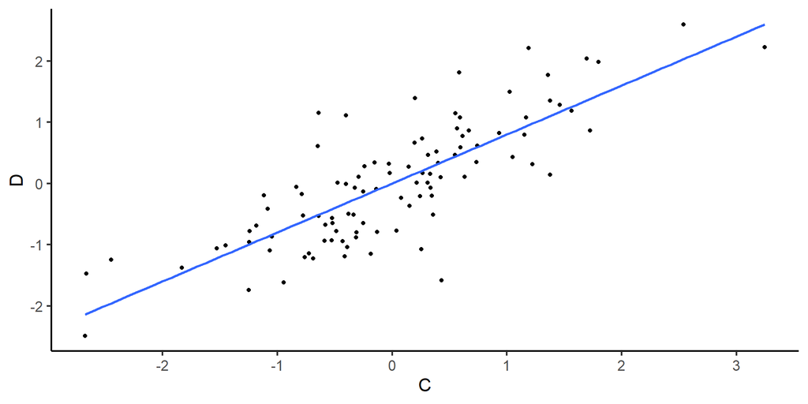

## 6.3 R-squared multiple

- We’ll talk more about $R^2_{multiple}$
  - Estimation
  - Effect size
  - Logistic regression and Poisson regression

# 7 Presenting results

## 7.1 Packages to show model results

- `summary()` function from **base** R
- `summ()` function from **jtools** package
- `modelsummary()` function in **modelsummary** package
  - Nice HTML output, multiple models in one table
- Non-exhaustive list

## 7.2 Example 1: `summary()`

```r
summary(pulse_vs_age)
```

```
Call:
lm(formula = Pulse ~ Age, data = ICU)

Residuals:
    Min      1Q  Median      3Q     Max
-59.998 -18.098  -4.123  19.452  92.402

Coefficients:
            Estimate Std. Error t value Pr(>|t|)
(Intercept) 96.04818    5.78821  16.594   <2e-16 ***
Age          0.04999    0.09501   0.526    0.599
---
Signif. codes:  0 '***' 0.001 '**' 0.01 '*' 0.05 '.' 0.1 ' ' 1

Residual standard error: 26.88 on 198 degrees of freedom
Multiple R-squared:  0.001396,  Adjusted R-squared:  -0.003647
F-statistic: 0.2769 on 1 and 198 DF,  p-value: 0.5993
```

## 7.3 Example 1: `summ()`

```r
library(jtools)
summ(pulse_vs_age)
```

| Observations | 200 |
| --- | --- |
| Dependent variable | Pulse |
| Type | OLS linear regression |

| F(1,198) | 0.28 |
| --- | --- |
| R² | 0.00 |
| Adj. R² | -0.00 |

|  | Est. | S.E. | t val. | p |
| --- | --- | --- | --- | --- |
| (Intercept) | 96.05 | 5.79 | 16.59 | 0.00 |
| Age | 0.05 | 0.10 | 0.53 | 0.60 |

Standard errors: OLS

## 7.4 Example 1: `modelsummary()`

```r
library(modelsummary)
modelsummary(pulse_vs_age)
```

|  | (1) |
| --- | --- |
| (Intercept) | 96.048 |
|  | (5.788) |
| Age | 0.050 |
|  | (0.095) |
| Num.Obs. | 200 |
| R2 | 0.001 |
| R2 Adj. | -0.004 |
| AIC | 1888.1 |
| BIC | 1898.0 |
| Log.Lik. | -941.048 |
| F | 0.277 |
| RMSE | 26.74 |

## 7.5 Example 1: `summary()` + `kableExtra()`

```r
library(kableExtra)
kable(summary(pulse_vs_age)$coefficients)
```

|  | Estimate | Std. Error | t value | Pr(>\|t\|) |
| --- | --- | --- | --- | --- |
| (Intercept) | 96.0481848 | 5.7882105 | 16.593761 | 0.0000000 |
| Age | 0.0499924 | 0.0950087 | 0.526188 | 0.5993465 |

## 7.6 Example 2: `summary()`

```r
summary(pulse_vs_ER)
```

```
Call:
lm(formula = Pulse ~ Emergency, data = ICU)

Residuals:
    Min      1Q  Median      3Q     Max
-62.741 -17.741  -2.927  18.259  90.259

Coefficients:
            Estimate Std. Error t value Pr(>|t|)
(Intercept)   91.113      3.637  25.049   <2e-16 ***
Emergency     10.628      4.243   2.505   0.0131 *
---
Signif. codes:  0 '***' 0.001 '**' 0.01 '*' 0.05 '.' 0.1 ' ' 1

Residual standard error: 26.48 on 198 degrees of freedom
Multiple R-squared:  0.03072,   Adjusted R-squared:  0.02582
F-statistic: 6.275 on 1 and 198 DF,  p-value: 0.01305
```

## 7.7 Example 2: `summ()`

```r
library(jtools)
summ(pulse_vs_ER)
```

| Observations | 200 |
| --- | --- |
| Dependent variable | Pulse |
| Type | OLS linear regression |

| F(1,198) | 6.28 |
| --- | --- |
| R² | 0.03 |
| Adj. R² | 0.03 |

|  | Est. | S.E. | t val. | p |
| --- | --- | --- | --- | --- |
| (Intercept) | 91.11 | 3.64 | 25.05 | 0.00 |
| Emergency | 10.63 | 4.24 | 2.51 | 0.01 |

Standard errors: OLS

## 7.8 Example 2: `modelsummary()`

```r
library(modelsummary)
modelsummary(pulse_vs_ER)
```

|  | (1) |
| --- | --- |
| (Intercept) | 91.113 |
|  | (3.637) |
| Emergency | 10.628 |
|  | (4.243) |
| Num.Obs. | 200 |
| R2 | 0.031 |
| R2 Adj. | 0.026 |
| AIC | 1882.1 |
| BIC | 1892.0 |
| Log.Lik. | -938.068 |
| F | 6.275 |
| RMSE | 26.35 |

## 7.9 Example 2: `summary()` + `kableExtra()`

```r
library(kableExtra)
kable(summary(pulse_vs_ER)$coefficients)
```

|  | Estimate | Std. Error | t value | Pr(>\|t\|) |
| --- | --- | --- | --- | --- |
| (Intercept) | 91.11321 | 3.637436 | 25.048745 | 0.0000000 |
| Emergency | 10.62829 | 4.242792 | 2.505023 | 0.0130508 |

## 7.10 Multiple models in `modelsummary()`

```r
library(modelsummary)
modelsummary(list(pulse_vs_age, pulse_vs_ER, pulse_age_ER))
```

|  | (1) | (2) | (3) |
| --- | --- | --- | --- |
| (Intercept) | 96.048 | 91.113 | 84.913 |
|  | (5.788) | (3.637) | (7.081) |
| Age | 0.050 |  | 0.097 |
|  | (0.095) |  | (0.095) |
| Emergency |  | 10.628 | 11.452 |
|  |  | (4.243) | (4.318) |
| Num.Obs. | 200 | 200 | 200 |
| R2 | 0.001 | 0.031 | 0.036 |
| R2 Adj. | -0.004 | 0.026 | 0.026 |
| AIC | 1888.1 | 1882.1 | 1883.1 |
| BIC | 1898.0 | 1892.0 | 1896.3 |
| Log.Lik. | -941.048 | -938.068 | -937.540 |
| F | 0.277 | 6.275 | 3.659 |
| RMSE | 26.74 | 26.35 | 26.28 |

## 7.12 Example 2: Full results

- The intercept ($b_0$) was 91.113, $t(1)$ = 25.049, $p$ < .0001. An individual who had a non-emergency admission is expected to have a pulse rate of 91.113.
- The slope for type of admission ($b_1$) was 10.628, $t(1)$ = 2.505, $p$ < .05. The difference in expected pulse rate between non-emergency admissions (0) and emergency admissions (1) was 10.628 points.
- The $R^2$ for this model was 0.0307, F(1, 198) = 6.275, p < .05. About 3% of the variance in pulse rate was explained by admission type.

# 8 Next time

## 8.1 Expanding the model

- More complicated models
  - Two or more predictors
  - Non-linear relationships, interaction (moderator) effects
- Predictor coding and centering
- Comparing models
- More interpretation, more checking assumptions
- Estimation of the model